# Clasificación de perros y gatos

`Fernando Gómez Herrera A01020319`

**Objective**: Create a classifier to detect dogs and cats from images.

**Dataset**: The dataset can be obtained from this [Kaggle's competition.](https://www.kaggle.com/c/dogs-vs-cats)

# Índice

> > Downloading the dataset

> > Neural Network Architecture

> > Training

> > Test accuracy

> > Segundo experimento

> > Tercer experimento

> > Cuarto experimento

> > Resultados

> Conclusiones

```python
!pip install PyDrive keras bokeh seaborn
```

[output not shown]

```python
import tensorflow as tf
device_name = tf.test.gpu_device_name()
print(device_name)
if device_name: print('Found GPU at: {}'.format(device_name))
tf.device(device_name)
```

```
/device:GPU:0
Found GPU at: /device:GPU:0
```

```
<contextlib._GeneratorContextManager at 0x7ffbdc894f98>
```

## Downloading the dataset

```python
from pydrive.auth import GoogleAuth
from pydrive.drive import GoogleDrive
from google.colab import auth
from oauth2client.client import GoogleCredentials

# Authenticate and create the PyDrive client.
# This only needs to be done once per notebook.
auth.authenticate_user()
gauth = GoogleAuth()
gauth.credentials = GoogleCredentials.get_application_default()
drive = GoogleDrive(gauth)

# List .txt files in the root.
#
# Search query reference:
# https://developers.google.com/drive/v2/web/search-parameters
#listed = drive.ListFile({'q': "title contains '.zip'"}).GetList()
# file.GetContentString()
```

```python
file = drive.CreateFile({ 'id': '1a1SNRKzkSmaFIS_uS-RP9e24mfcFE4bF' })
file.GetContentFile('cats_vs_dogs.zip')
```

```python
!unzip cats_vs_dogs.zip | tail
```

```
  inflating: __MACOSX/cats_vs_dogs/validation/cats/._cat.8238.jpg
  inflating: cats_vs_dogs/validation/cats/cat.9126.jpg
  inflating: __MACOSX/cats_vs_dogs/validation/cats/._cat.9126.jpg
  inflating: cats_vs_dogs/validation/cats/cat.9132.jpg
  inflating: __MACOSX/cats_vs_dogs/validation/cats/._cat.9132.jpg
  inflating: cats_vs_dogs/validation/cats/cat.9654.jpg
  inflating: __MACOSX/cats_vs_dogs/validation/cats/._cat.9654.jpg
  inflating: cats_vs_dogs/validation/cats/cat.7679.jpg
  inflating: __MACOSX/cats_vs_dogs/validation/cats/._cat.7679.jpg
  inflating: __MACOSX/cats_vs_dogs/._validation
```

```python
%matplotlib inline
import keras
from keras.models import Sequential
from keras import layers
from keras.preprocessing.image import load_img
from collections import Counter
import pandas as pd
import numpy as np
import seaborn as sns
import matplotlib.pyplot as plt
from keras.preprocessing.image import ImageDataGenerator, array_to_img, img_to_array
from keras.layers import Conv2D, MaxPooling2D
from keras.layers import Activation, Dropout, Flatten, Dense, Reshape
from keras import optimizers
from keras import layers
from keras import models
from keras import optimizers
from keras import regularizers
from keras.callbacks import TensorBoard
```

```python
def _plot(model_fit):
  validation = model_fit.history['val_acc']
  train = model_fit.history['acc']
  max_val_acc = max(validation)
  epoch = validation.index(max_val_acc)

  plt.plot(train, 'bo', label="Training Accuracy")
  plt.plot(validation, 'b', label="Validation Accuracy")
  plt.title("Training Acc. vs Validation Acc.")
  plt.legend()
  plt.show()

  print(f"Max. Validation Accuracy: {max_val_acc:.3f} at epoch #{epoch}")
  print(f"Training accuracy at epoch #{epoch}: {train[epoch]:.3f}")
```

```python
PATH = !echo "$HOME/cats_vs_dogs"
PATH = PATH[0]
print(f"Dataset path: {PATH}")
```

```
Dataset path: /content/cats_vs_dogs
```

```python
# Generation of images and data feeders
BATCH_SIZE = 64
TRAIN_SIZE = 7500
VALIDATION_SIZE = 2500
TEST_SIZE = 2500

_KEYS = ['train', 'validation', 'test']
_IMG_GEN = {key: ImageDataGenerator(rescale = 1./255, data_format='channels_last') for key in _KEYS}

OPTS = dict(target_size=(150, 150), batch_size=BATCH_SIZE, class_mode='binary')
GENERATORS = {key: _IMG_GEN[key].flow_from_directory(f"{PATH}/{key}", **OPTS) for key in _KEYS}
```

```
Found 15000 images belonging to 2 classes.
Found 5000 images belonging to 2 classes.
Found 5000 images belonging to 2 classes.
```

# Neural Network Architecture

## Primer experimento

```python
tf.device(device_name)
# tensorBoard = TensorBoard(log_dir='./logs', batch_size=BATCH_SIZE)

model = models.Sequential()
model.add(layers.Flatten(input_shape=(150, 150, 3)))
model.add(layers.Dense(512, activation='relu'))
model.add(layers.Dense(512, activation='relu'))
model.add(layers.Dense(512, activation='relu'))
model.add(layers.Dropout(0.5))
model.add(layers.Dense(512, activation='relu'))
model.add(layers.Dense(512, activation='relu'))
model.add(layers.Dense(1, activation='sigmoid'))

model.compile(optimizer=keras.optimizers.SGD(lr=0.01,
                                             momentum=0.1, decay=0.1,
                                             nesterov=True),
              loss='binary_crossentropy',
              metrics=['accuracy'])
model.summary()
```

```
_________________________________________________________________
Layer (type)                 Output Shape              Param #
=================================================================
flatten_4 (Flatten)          (None, 67500)             0
_________________________________________________________________
dense_23 (Dense)             (None, 512)               34560512
_________________________________________________________________
dense_24 (Dense)             (None, 512)               262656
_________________________________________________________________
dense_25 (Dense)             (None, 512)               262656
_________________________________________________________________
dropout_4 (Dropout)          (None, 512)               0
_________________________________________________________________
dense_26 (Dense)             (None, 512)               262656
_________________________________________________________________
dense_27 (Dense)             (None, 512)               262656
_________________________________________________________________
dense_28 (Dense)             (None, 1)                 513
=================================================================
Total params: 35,611,649
Trainable params: 35,611,649
Non-trainable params: 0
_________________________________________________________________
```

```python
model_fit = model.fit_generator(GENERATORS['train'],
                   steps_per_epoch=TRAIN_SIZE // BATCH_SIZE,
                   validation_data=GENERATORS['validation'],
                   validation_steps=VALIDATION_SIZE // BATCH_SIZE,
#                               callbacks=[tensorBoard],
                   epochs=100)
```

[output not shown]

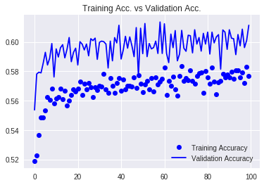

```
Max. Validation Accuracy: 0.614 at epoch #58
Training accuracy at epoch #58: 0.573
```

```python
train_acc = model_fit.history['acc']
val_acc   = model_fit.history['val_acc']
_plot(train_acc, val_acc)
```

```python
# Evaluation of the model using the test dataset
evaluation = model_fit.model.evaluate_generator(GENERATORS['test']);
```

Test accuracy

```python
[print(f"{metric:10s}: {value:.3f}") for metric,value in zip(model_fit.model.metrics_names, evaluation)];
```

```
loss      : 0.677
acc       : 0.579
```

## Segundo experimento

```python
tf.device(device_name)
# tensorBoard = TensorBoard(log_dir='./logs', batch_size=BATCH_SIZE)

model = models.Sequential()
model.add(layers.Flatten(input_shape=(150, 150, 3)))
model.add(layers.Dense(512,
                       kernel_regularizer=keras.regularizers.l1_l2(),
                       activation='relu'))
model.add(layers.Dense(512, activation='relu'))
model.add(layers.Dense(512, activation='relu'))
model.add(layers.Dense(512, activation='relu'))
model.add(layers.Dense(512, activation='relu'))
model.add(layers.Dropout(0.5))
model.add(layers.Dense(512, activation='relu'))
model.add(layers.Dense(512, activation='relu'))
model.add(layers.Dropout(0.5))
model.add(layers.Dense(512, activation='relu'))
model.add(layers.Dense(1, activation='sigmoid'))

model.compile(optimizer=keras.optimizers.SGD(lr=0.02,
                                             momentum=0.8, decay=0.8,
                                             nesterov=True),
              loss='binary_crossentropy',
              metrics=['accuracy'])
model.summary()
```

```
_________________________________________________________________
Layer (type)                 Output Shape              Param #
=================================================================
flatten_8 (Flatten)          (None, 67500)             0
_________________________________________________________________
dense_59 (Dense)             (None, 512)               34560512
_________________________________________________________________
dense_60 (Dense)             (None, 512)               262656
_________________________________________________________________
dense_61 (Dense)             (None, 512)               262656
_________________________________________________________________
dense_62 (Dense)             (None, 512)               262656
_________________________________________________________________
dense_63 (Dense)             (None, 512)               262656
_________________________________________________________________
dropout_6 (Dropout)          (None, 512)               0
_________________________________________________________________
dense_64 (Dense)             (None, 512)               262656
_________________________________________________________________
dense_65 (Dense)             (None, 512)               262656
_________________________________________________________________
dropout_7 (Dropout)          (None, 512)               0
_________________________________________________________________
dense_66 (Dense)             (None, 512)               262656
_________________________________________________________________
dense_67 (Dense)             (None, 1)                 513
=================================================================
Total params: 36,399,617
Trainable params: 36,399,617
Non-trainable params: 0
_________________________________________________________________
```

```python
model_fit = model.fit_generator(GENERATORS['train'],
                   steps_per_epoch=TRAIN_SIZE // BATCH_SIZE,
                   validation_data=GENERATORS['validation'],
                   validation_steps=VALIDATION_SIZE // BATCH_SIZE,
                   callbacks=[checkpoint],
                   epochs=60)
```

[output not shown]

[output cut: 64 more lines]

```
Epoch 00053: loss did not improve

Epoch 00054: loss did not improve

Epoch 00055: loss did not improve

Epoch 00056: loss did not improve

Epoch 00057: loss did not improve

Epoch 00058: loss did not improve

Epoch 00059: loss did not improve

Epoch 00060: loss did not improve
```

```python
model = keras.models.load_model("cats_model.h5")
```

[figure not shown]

[output not shown]

```python
_plot(model_fit.history['acc'], model_fit.history['val_acc'])
```

```python
evaluation = model_fit.model.evaluate_generator(GENERATORS['test']);
```

```python
[print(f"{metric:10s}: {value:.3f}") for metric,value in zip(model_fit.model.metrics_names, evaluation)];
```

```
loss      : 0.681
acc       : 0.586
```

## Tercer experimento

```python
from keras.callbacks import ModelCheckpoint
checkpoint = ModelCheckpoint(filepath='best_model.h5',
                             monitor='val_acc',
                             mode='max',
                             verbose=1, save_best_only=True)


model = models.Sequential()
model.add(layers.Flatten(input_shape=(150, 150, 3)))
model.add(layers.Dropout(0.2))
model.add(layers.Dense(512, activation='relu'))
model.add(layers.Dense(512, activation='relu'))
model.add(layers.Dropout(0.5))
model.add(layers.Dense(512, activation='relu'))
model.add(layers.Dense(1, activation='sigmoid'))

model.compile(optimizer=keras.optimizers.SGD(lr=0.01,
                                             momentum=0.5, decay=0.5,
                                             nesterov=True),
              loss='binary_crossentropy',
              metrics=['accuracy'])
print(model.summary())
model_fit = model.fit_generator(GENERATORS['train'],
                   steps_per_epoch=TRAIN_SIZE // BATCH_SIZE,
                   validation_data=GENERATORS['validation'],
                   validation_steps=VALIDATION_SIZE // BATCH_SIZE,
                   callbacks=[checkpoint],
                   epochs=60)
evaluation = model_fit.model.evaluate_generator(GENERATORS['test']);
print("Test evaluation")
[print(f"{metric:10s}: {value:.3f}") for metric,value in zip(model_fit.model.metrics_names, evaluation)];
```

```
_________________________________________________________________
Layer (type)                 Output Shape              Param #
=================================================================
flatten_2 (Flatten)          (None, 67500)             0
_________________________________________________________________
dropout_3 (Dropout)          (None, 67500)             0
_________________________________________________________________
dense_5 (Dense)              (None, 512)               34560512
_________________________________________________________________
dense_6 (Dense)              (None, 512)               262656
_________________________________________________________________
dropout_4 (Dropout)          (None, 512)               0
_________________________________________________________________
dense_7 (Dense)              (None, 512)               262656
_________________________________________________________________
dense_8 (Dense)              (None, 1)                 513
=================================================================
Total params: 35,086,337
Trainable params: 35,086,337
Non-trainable params: 0
_________________________________________________________________
None
WARNING:tensorflow:Variable *= will be deprecated. Use variable.assign_mul if you want assignment to the variable value or 'x = x * y' if you want a new python Tensor object.

Epoch 00001: val_acc improved from -inf to 0.55489, saving model to best_model.h5

Epoch 00002: val_acc improved from 0.55489 to 0.56170, saving model to best_model.h5

Epoch 00003: val_acc improved from 0.56170 to 0.57131, saving model to best_model.h5

Epoch 00004: val_acc improved from 0.57131 to 0.57212, saving model to best_model.h5

Epoch 00005: val_acc did not improve

Epoch 00006: val_acc did not improve

Epoch 00007: val_acc did not improve

Epoch 00008: val_acc improved from 0.57212 to 0.58333, saving model to best_model.h5

```

[output cut: 40 more lines]

```
Epoch 00029: val_acc did not improve

Epoch 00030: val_acc did not improve

Epoch 00031: val_acc did not improve

Epoch 00032: val_acc did not improve

Epoch 00033: val_acc did not improve

Epoch 00034: val_acc did not improve

Epoch 00035: val_acc did not improve

Epoch 00036: val_acc did not improve
```

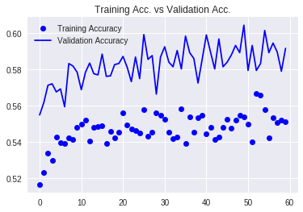

```
Max. Validation Accuracy: 0.605 at epoch #49
Training accuracy at epoch #49: 0.554
Test evaluation
loss      : 0.679
acc       : 0.575
```

```python
_plot(model_fit)
evaluation = model_fit.model.evaluate_generator(GENERATORS['test']);
print("Test evaluation")
[print(f"{metric:10s}: {value:.3f}") for metric,value in zip(model_fit.model.metrics_names, evaluation)];
```

## Cuarto experimento

```
_________________________________________________________________
Layer (type)                 Output Shape              Param #
=================================================================
flatten_5 (Flatten)          (None, 67500)             0
_________________________________________________________________
dense_19 (Dense)             (None, 512)               34560512
_________________________________________________________________
dense_20 (Dense)             (None, 512)               262656
_________________________________________________________________
dense_21 (Dense)             (None, 512)               262656
_________________________________________________________________
dense_22 (Dense)             (None, 512)               262656
_________________________________________________________________
dense_23 (Dense)             (None, 1)                 513
=================================================================
Total params: 35,348,993
Trainable params: 35,348,993
Non-trainable params: 0
_________________________________________________________________
None

Epoch 00001: val_acc improved from -inf to 0.49960, saving model to best_model.h5

Epoch 00002: val_acc improved from 0.49960 to 0.50120, saving model to best_model.h5

Epoch 00003: val_acc did not improve

Epoch 00004: val_acc improved from 0.50120 to 0.50441, saving model to best_model.h5

Epoch 00005: val_acc did not improve

Epoch 00006: val_acc improved from 0.50441 to 0.51643, saving model to best_model.h5

Epoch 00007: val_acc did not improve

Epoch 00008: val_acc did not improve

Epoch 00009: val_acc did not improve

Epoch 00010: val_acc did not improve
```

[output cut: 85 more lines]

```
Epoch 00053: val_acc did not improve

Epoch 00054: val_acc did not improve

Epoch 00055: val_acc did not improve

Epoch 00056: val_acc did not improve

Epoch 00057: val_acc did not improve

Epoch 00058: val_acc did not improve

Epoch 00059: val_acc did not improve

Epoch 00060: val_acc did not improve
```

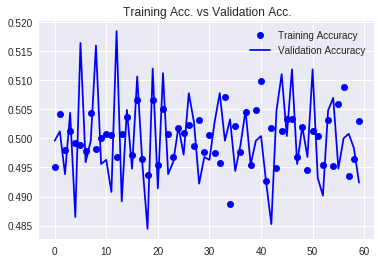

```
Max. Validation Accuracy: 0.518 at epoch #12
Training accuracy at epoch #12: 0.497
Test evaluation
loss      : 8.059
acc       : 0.500
```

```python
from keras.callbacks import ModelCheckpoint
checkpoint = ModelCheckpoint(filepath='best_model.h5',
                             monitor='val_acc',
                             mode='max',
                             verbose=1, save_best_only=True)


model = models.Sequential()
model.add(layers.Flatten(input_shape=(150, 150, 3)))
model.add(layers.Dense(512, activation='relu'))
model.add(layers.Dense(512, activation='relu'))
model.add(layers.Dense(512, activation='relu'))
model.add(layers.Dense(512, activation='relu'))
model.add(layers.Dense(1, activation='sigmoid'))

model.compile(optimizer=keras.optimizers.RMSprop(),
              loss='binary_crossentropy',
              metrics=['accuracy'])
print(model.summary())
model_fit = model.fit_generator(GENERATORS['train'],
                   steps_per_epoch=TRAIN_SIZE  // BATCH_SIZE,
                   validation_data=GENERATORS['validation'],
                   validation_steps=VALIDATION_SIZE // BATCH_SIZE,
                   callbacks=[checkpoint],
                   epochs=60)
_plot(model_fit)
evaluation = model_fit.model.evaluate_generator(GENERATORS['test']);
print("Test evaluation")
[print(f"{metric:10s}: {value:.3f}") for metric,value in zip(model_fit.model.metrics_names, evaluation)];
```

## Quinto experimento

```
_________________________________________________________________
Layer (type)                 Output Shape              Param #
=================================================================
flatten_6 (Flatten)          (None, 67500)             0
_________________________________________________________________
dense_24 (Dense)             (None, 512)               34560512
_________________________________________________________________
dense_25 (Dense)             (None, 512)               262656
_________________________________________________________________
dense_26 (Dense)             (None, 512)               262656
_________________________________________________________________
dense_27 (Dense)             (None, 512)               262656
_________________________________________________________________
dense_28 (Dense)             (None, 1)                 513
=================================================================
Total params: 35,348,993
Trainable params: 35,348,993
Non-trainable params: 0
_________________________________________________________________
None

Epoch 00001: val_acc improved from -inf to 0.49920, saving model to best_model.h5

Epoch 00002: val_acc improved from 0.49920 to 0.50040, saving model to best_model.h5

Epoch 00003: val_acc improved from 0.50040 to 0.50615, saving model to best_model.h5

Epoch 00004: val_acc did not improve

Epoch 00005: val_acc did not improve

Epoch 00006: val_acc did not improve

Epoch 00007: val_acc did not improve

Epoch 00008: val_acc did not improve

Epoch 00009: val_acc did not improve

Epoch 00010: val_acc improved from 0.50615 to 0.51122, saving model to best_model.h5
```

[output cut: 85 more lines]

```
Epoch 00053: val_acc improved from 0.51322 to 0.52090, saving model to best_model.h5

Epoch 00054: val_acc did not improve

Epoch 00055: val_acc did not improve

Epoch 00056: val_acc did not improve

Epoch 00057: val_acc did not improve

Epoch 00058: val_acc did not improve

Epoch 00059: val_acc did not improve

Epoch 00060: val_acc did not improve
```

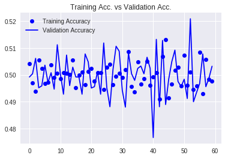

```
Max. Validation Accuracy: 0.521 at epoch #52
Training accuracy at epoch #52: 0.501
Test evaluation
loss      : 7.971
acc       : 0.500
```

```python
from keras.callbacks import ModelCheckpoint
checkpoint = ModelCheckpoint(filepath='best_model.h5',
                             monitor='val_acc',
                             mode='max',
                             verbose=1, save_best_only=True)


model = models.Sequential()
model.add(layers.Flatten(input_shape=(150, 150, 3)))
model.add(layers.Dense(512, activation='relu'))
model.add(layers.Dense(512, activation='relu'))
model.add(layers.Dense(512, activation='relu'))
model.add(layers.Dense(512, activation='relu'))
model.add(layers.Dense(1, activation='sigmoid'))

model.compile(optimizer=keras.optimizers.Adagrad(),
              loss='binary_crossentropy',
              metrics=['accuracy'])
print(model.summary())
model_fit = model.fit_generator(GENERATORS['train'],
                   steps_per_epoch=TRAIN_SIZE  // BATCH_SIZE,
                   validation_data=GENERATORS['validation'],
                   validation_steps=VALIDATION_SIZE // BATCH_SIZE,
                   callbacks=[checkpoint],
                   epochs=60)
_plot(model_fit)
evaluation = model_fit.model.evaluate_generator(GENERATORS['test']);
print("Test evaluation")
[print(f"{metric:10s}: {value:.3f}") for metric,value in zip(model_fit.model.metrics_names, evaluation)];
```

## Sexto experimento

```python
from keras.callbacks import ModelCheckpoint
checkpoint = ModelCheckpoint(filepath='best_model.h5',
                             monitor='val_acc',
                             mode='max',
                             verbose=1, save_best_only=True)


model = models.Sequential()
model.add(layers.Flatten(input_shape=(150, 150, 3)))
model.add(layers.Dropout(0.2))
model.add(layers.Dense(1024, activation='relu'))
model.add(layers.Dense(1024, activation='relu'))
model.add(layers.Dropout(0.5))
model.add(layers.Dense(1024, activation='relu'))
model.add(layers.Dense(1024, activation='relu'))
model.add(layers.Dense(1, activation='sigmoid'))

model.compile(optimizer=keras.optimizers.Adagrad(),
              loss='binary_crossentropy',
              metrics=['accuracy'])
print(model.summary())
model_fit = model.fit_generator(GENERATORS['train'],
                   steps_per_epoch=TRAIN_SIZE * 1.2  // BATCH_SIZE,
                   validation_data=GENERATORS['validation'],
                   validation_steps=VALIDATION_SIZE // BATCH_SIZE,
                   callbacks=[checkpoint],
                   epochs=60)
```

```
_________________________________________________________________
Layer (type)                 Output Shape              Param #
=================================================================
flatten_7 (Flatten)          (None, 67500)             0
_________________________________________________________________
dropout_5 (Dropout)          (None, 67500)             0
_________________________________________________________________
dense_29 (Dense)             (None, 1024)              69121024
_________________________________________________________________
dense_30 (Dense)             (None, 1024)              1049600
_________________________________________________________________
dropout_6 (Dropout)          (None, 1024)              0
_________________________________________________________________
dense_31 (Dense)             (None, 1024)              1049600
_________________________________________________________________
dense_32 (Dense)             (None, 1024)              1049600
_________________________________________________________________
dense_33 (Dense)             (None, 1)                 1025
=================================================================
Total params: 72,270,849
Trainable params: 72,270,849
Non-trainable params: 0
_________________________________________________________________
None

Epoch 00001: val_acc improved from -inf to 0.50841, saving model to best_model.h5

Epoch 00002: val_acc did not improve

Epoch 00003: val_acc did not improve

Epoch 00004: val_acc did not improve

Epoch 00005: val_acc did not improve

Epoch 00006: val_acc did not improve

Epoch 00007: val_acc did not improve

Epoch 00008: val_acc did not improve
```

[output cut: 31 more lines]

```
Epoch 00024: val_acc did not improve

Epoch 00025: val_acc did not improve

Epoch 00026: val_acc did not improve

Epoch 00027: val_acc did not improve

Epoch 00028: val_acc did not improve

Epoch 00029: val_acc did not improve

Epoch 00030: val_acc did not improve

Epoch 00031: val_acc did not improve
```

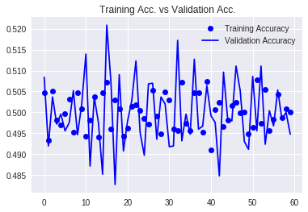

```
Max. Validation Accuracy: 0.521 at epoch #15
Training accuracy at epoch #15: 0.507
Test evaluation
loss      : 8.059
acc       : 0.500
```

```python
_plot(model_fit)
evaluation = model_fit.model.evaluate_generator(GENERATORS['test']);
print("Test evaluation")
[print(f"{metric:10s}: {value:.3f}") for metric,value in zip(model_fit.model.metrics_names, evaluation)];
```

## Resultados

[output not shown]

Donde la columna modelo puede ser interpretada de la siguiente forma:

**e.g.** `3x(512)-D(0.5)-2x(512)` => Arquitectura de 3 capas con 512 unidades, una capa de Dropout con `p=0.5` y dos capas de 512 unidades.

- Los parámetros de **SGD** son una tupla de la forma **`(learning rate, momentum, decay, nesterov)`**
- Los parámetros de **RMSprop** son una tupla de la forma **`(learning rate)`**
- Todos los experimentos utilizan **ReLu** como función de activación.

# Conclusiones

La elaboración de esta práctica resultó muy retadora por múltiples razones. Primero, conseguir y estructurar un conjunto de datos muy grande. Segundo, crear un modelo que pueda aceptar tantos datos de entrada. Tercero, entrenar la red neuronal para que identifique imágenes muy diferentes con un buen desempeño.

Sufrí mucho debido a que mi computadora no cuenta con suficientes recursos para hacer el procesamiento. Cargar tantas imágenes provocaba que mi computadora se congelara. No obstante, pude resolver la práctica utilizando **Google CoLab**, donde tuve acceso a un GPU y también a mayor capacidad de procesamiento. De igual forma, el API de Keras me ayudó para entrenar el modelo en *batches* y no cargar todo en memoria directamente, sin eso probablemente no hubiera conseguido hacer el entrenamiento de forma fácil.

Busqué varios tutoriales de Keras y la mayoría utilizaba redes pre-entrenadas y con capas de convolución. Dichos modelos tenían un rendimiento mucho mayor, como de 80-90% de precisión, sin embargo, debido a los requerimientos del módulo de la clase aún no implementé ninguna de esas arquitecturas.

Lo anterior me lleva a la conclusión de que la arquitectura de red neuronal densa no se desempeña muy bien para clasificación de imágenes complejas, y que utilizar capas de convolución es la mejor manera de acercarse al resultado deseado.

No obstante, es interesante para mí que en la práctica anterior del MNIST, sin capas de convolución obtuvimos muy buenos resultados; he de suponer que es por la complejidad de las imágenes. Sin embargo, esperaba obtener una precisión similar a la de la práctica pasada y terminé un poco desanimado.